# Diferenciación de células 3T3-L1 a adipocitos

UIEEN-PL-025

Autores/as

Afiliaciones

Diana Villalpando Sánchez

Tuneado por

Oscar Medina Contreras

Revisó

Oscar Medina Contreras

Autorizó

Fecha de publicación

31 de octubre de 2025

**NotaPropósito**

Diferenciar células 3T3-L1 a adipocitos maduros

**NotaAlcance**

Este procedimiento involucra a todo el personal técnico, científico y estudiantes que realicen cultivo celular y que necesiten diferenciar células 3T3-L1 a adipocitos en la Unidad de Investigación Epidemiológica en Endocrinología y Nutrición del Hospital Infantil de México Federico Gómez

**NotaPolíticas de operación, normas y lineamientos**

Es responsabilidad de todo el personal científico, estudiantes y técnicos adscritos a la Unidad de Investigación Epidemiológica en Endocrinología y Nutrición del Hospital Infantil de México Federico Gómez conocer y dar seguimiento a este procedimiento. Los residuos de tipo CRETI (Corrosivas, Reactivas, Explosivas, Toxicas e Inflamables) se deberán eliminar con base en su clasificación y especificaciones de manejo según la Norma Oficial Mexicana NOM-087-ECOL-SSA1-2002; así como sus características intrínsecas y su toxicidad al ambiente según la NOM-052- SEMARNAT-2005

# Descripción del Protocolo

**NotaPasos**

**PrecauciónNotas**

La presencia de gotas de lípidos podrá ser observadas en las células a partir del día 8. Durante la diferenciación de las células se observará un cambio morfológico, aproximadamente en el día 12. Es importante revisar el cultivo cada 24 horas para realizar el cambio del MD correspondiente cuando resulte necesario. Durante el proceso de diferenciación no debe perderse más del 10% de células

## Diagrama de Flujo

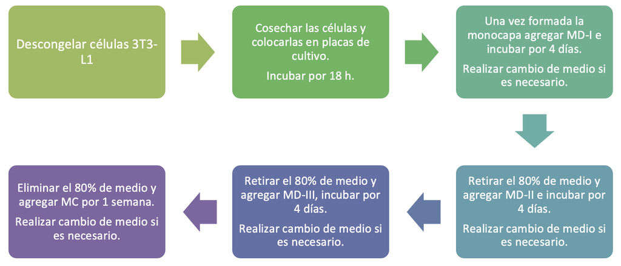

Figura 1. Diagrama de flujo

## Anexos

### Soluciones

2. Medios de diferenciación (MD) La siguiente tabla es descrita para cada mililitro (1 mL) de MD a preparar. Al MC se le adicionara los reactivos necesarios para preparar los medios de diferenciación:

1. Medio de crecimiento

Medio DMEM + 10% SFB + antibiótico/antimicótico + l-glutamina

2. Medios de diferenciación (MD)

Al medio de crecimiento se le adicionara los reactivos necesarios para preparar los medios de diferenciación. La siguiente tabla es descrita para 3 mL de medio, es decir para un pozo.

Tabla 1: **medios de diferenciación**

[output not shown]

<sup>1</sup> de una dilución 1:10 (9$\mu$L de medio de crecimiento + 1$\mu$L de rosiglitazona 20 Mm)

## Documentos de referencia

Zebisch K, Voigt V, Wabitsch M, Brandsch M. Protocol for effective differentiation of 3T3-L1 cells to adipocytes. Analytical biochemistry. 2012;425(1):88-90. Zebisch K, Voigt V, Wabitsch M, Brandsch M. Protocol for effective differentiation of 3T3-L1 cells to adipocytes. Analytical biochemistry. 2012;425(1):88-90.

# Project Summary: A Vision for Holistic Healing

Childhood cancer is a global tragedy, but its burden is not shared equally. In Mexico, a child diagnosed with leukemia faces a 57% chance of survival, a stark contrast to the 90% survival rate in high-income nations. This devastating gap is not just due to access to drugs but to the complications that arise during treatment, such as life-threatening infections and Graft-versus-Host Disease (GVHD). Our project posits that a key, overlooked factor in this disparity lies within us: the **gut microbiota**, our personal inner ecosystem.

This proposal outlines a pioneering study at the Hospital Infantil de México to understand how chemotherapy disrupts this vital microbial community and how this disruption impacts treatment success. We will go beyond mere observation to identify predictive biomarkers and lay the scientific foundation for a revolutionary, low-cost intervention: **microbiome restoration therapy**[^2].

<sup>2</sup> e.g., Fecal Microbiota Transplantation - FMT.

Our vision is rooted in the **People-Microbiota-Planet** philosophy. We aim to heal **People** (vulnerable children) by understanding and restoring their **Microbiota** (their inner ecosystem), using a sustainable approach that mirrors the ecological principles of our **Planet**.

# **Alignment with the “People-Microbiota-Planet” Mission**

This project is conceived from the ground up to embody the principles of the Henri Boulard Award.

- **PEOPLE: Addressing Health Inequity in a Vulnerable Population** Our work is centered on the children of Mexico, a population facing a significant health disadvantage. By reducing treatment-related complications like infections and GVHD, we aim not only to increase survival rates but to dramatically improve the quality of life for young patients and their families. Our goal is to develop a tool that empowers clinicians to provide personalized, proactive care, turning a reactive battle against complications into a predictive strategy for success.
- **MICROBIOTA: From Symbiotic Partner to Therapeutic Agent** We view the microbiota not as a collection of germs, but as a symbiotic partner—a “forgotten organ” essential for immune function. Standard cancer treatments wage a war that causes collateral damage to this vital ally, leading to a state of *dysbiosis*, or a collapsed inner ecosystem. This project will decipher the complex dialogue between our gut microbes and our immune system during leukemia treatment. Our ultimate goal is to move from simply documenting this damage to actively **restoring** the symbiotic balance, transforming the microbiota from a casualty of war into a powerful agent of healing.
- **PLANET: An Ecological Approach to Sustainable Health** The health of our planet depends on biodiversity and ecological balance. The same is true for our inner world. This project adopts a “One Health” perspective, viewing the dysbiosis in a child’s gut as a microcosm of the biodiversity loss threatening our planet. The solutions we propose are inherently sustainable and ecological. Rather than relying solely on more resource-intensive pharmaceuticals to manage side effects, we are pioneering the use of **microbiome restoration**—a biological, restorative, and potentially low-cost therapy. FMT is the ultimate form of biological recycling, harnessing a healthy ecosystem to repair a damaged one. This approach represents a paradigm shift towards more sustainable, nature-based medicine that can be scaled globally, especially in resource-limited settings.

# **Project Description: From Problem to Solution**

**The Background: A Disrupted Ecosystem**

Chemotherapy and broad-spectrum antibiotics, the cornerstones of leukemia treatment, are indiscriminate. They save lives by killing cancer cells but also decimate the beneficial bacteria in the gut. This loss of microbial diversity cripples the immune system’s ability to distinguish friend from foe, leading to two major problems:

1. **Increased Infections:** The protective shield of good bacteria is gone, leaving the patient vulnerable to opportunistic pathogens.
2. **Graft-versus-Host Disease (GVHD):** After a stem cell transplant, a dysbiotic gut can trigger an aggressive immune reaction where the donor’s cells attack the patient’s body.

**Our Core Hypothesis:** Specific signatures of gut microbial dysbiosis *before* and *during* treatment predispose children with leukemia to poor outcomes. By identifying these signatures, we can predict risk and, more importantly, intervene to restore a healthy microbial ecosystem.

**Our Objectives:**

1. **To Map the Microbial Landscape of Leukemia:** We will use advanced sequencing to create the first comprehensive map of the gut microbiome in Mexican children with leukemia at different stages of treatment. This will allow us to identify specific “microbial signatures” associated with successful outcomes versus those linked to treatment failure, infections, and GVHD.
2. **To Decipher the Chemical Language of the Microbiome:** The microbiome communicates with our body through metabolites. Using high-resolution metabolomics (HPLC-Q-TOF-MS), we will identify the specific chemical signals—the “language”—associated with treatment rejection. This will provide a set of fast, non-invasive biomarkers that can be detected in a stool sample to predict a patient’s trajectory.
3. **To Pave the Way for Restorative Therapy:** In the lab, we will test how the “good” and “bad” bacteria we identify interact with human immune and intestinal cells. This will prove their functional role and provide the critical preclinical evidence needed to design future clinical trials using targeted probiotics or Fecal Microbiota Transplantation (FMT) at our hospital.

# **Expected Outcomes and Global Impact**

This project will deliver transformative results on multiple levels:

- **For Patients:** Identification of non-invasive biomarkers will enable doctors to predict which children are at high risk for complications, allowing for early, personalized intervention. This translates to fewer infections, less suffering, and better survival rates.
- **For Science:** We will generate a unique multi-omic dataset (genomics, metabolomics, immunology) that provides a deep understanding of the host-microbe interplay during cancer therapy. This knowledge will be applicable to other diseases where the microbiome is disrupted.
- **For Global Health:** Our most significant contribution will be laying the groundwork for implementing **low-cost, high-impact microbiome restoration therapies** in a public hospital setting. Success in Mexico City will create a blueprint for other low- and middle-income countries, offering a sustainable solution to close the global gap in cancer survival.

# **Conclusion: Seeding a Healthier Future**

This is more than a research project; it is a mission to redefine cancer care. By embracing the elegant, ecological principles that govern both our planet and our inner worlds, we can develop therapies that are not only more effective but also more humane and sustainable. By funding this work, the Henri Boulard Award will not only help save the lives of children in Mexico but will also champion a new paradigm in global health—one that recognizes the profound connection between **People, Microbiota, and Planet**.

# Henri Boulard Awards

## for a better Global Health “People-Microbiota-Planet”

To foster its commitment to improving health worldwide, the Biocodex Microbiota Foundation launched in 2021 the Henri Boulard Award.

Henri Boulard is the famous French microbiologist who discovered the yeast Saccharomyces boulardii in the 1920s in Indochina and its virtues against diarrhoea. The Henri Boulard Award is dedicated to improving the human conditions related to microbiota.

Because Gut Microbiota is more and more considered an organ, it deserves to be protected. Some factors such as Diet, Life style, Drugs or Environmental may impact microbiota leading to clinical disorders or diseases.

Actions such as educational programs, water purification, farming projects may preserve the organ integrity and may avoid the disorders associated with microbiota dysfunction.

That is why the Henri Boulard Award wants to support 4 initiatives: 2 related to microbiota and human health, 1 to microbiota and antimicrobial resistance prevention and 1 to microbiota and environmental concerns from 3 geographical areas: Asia, Latin America and Middle East Africa.

# Introduction

<sup>3</sup> To learn more, you can read more about [Quarto](https://www.quarto.org) or visit [Quarto’s Github repository](https://www.github.com/quarto-dev/quarto-cli).

```yaml
---
title: "Using the Tufte Style"
author: "John Smith"
format:
  html:
    grid:
      margin-width: 350px
  pdf: default
reference-location: margin
citation-location: margin
---
```

**1**

Increases the width of the margin to make more room for sidenotes and margin figures (HTML only).

**2**

Places footnotes and cited sources in the margin. Other layout options (for example placing a figure in the margin) will be set per element in examples below.

These layout features are designed with two important goals in mind:

1. To produce both PDF and HTML output with similar styles from the same Quarto document;
2. To provide simple syntax to write elements of the Tufte style such as side notes and margin figures. If you’d like a figure placed in the margin, just set the option `fig-column: margin` for your code chunk, and we will take care of the details for you[^4].

<sup>4</sup> You never need to think about `\begin{marginfigure}` or `<span class="marginfigure">`; the LaTeX and HTML code under the hood may be complicated, but you never need to learn or write such code.

If you have any feature requests or find bugs in these capabilities, please do not hesitate to file them to https://github.com/quarto-dev/quarto-cli/issues.

# Figures

## Margin Figures

Images and graphics play an integral role in Tufte’s work. To place figures in the margin you can use the **Quarto** chunk option `column: margin`. For example:

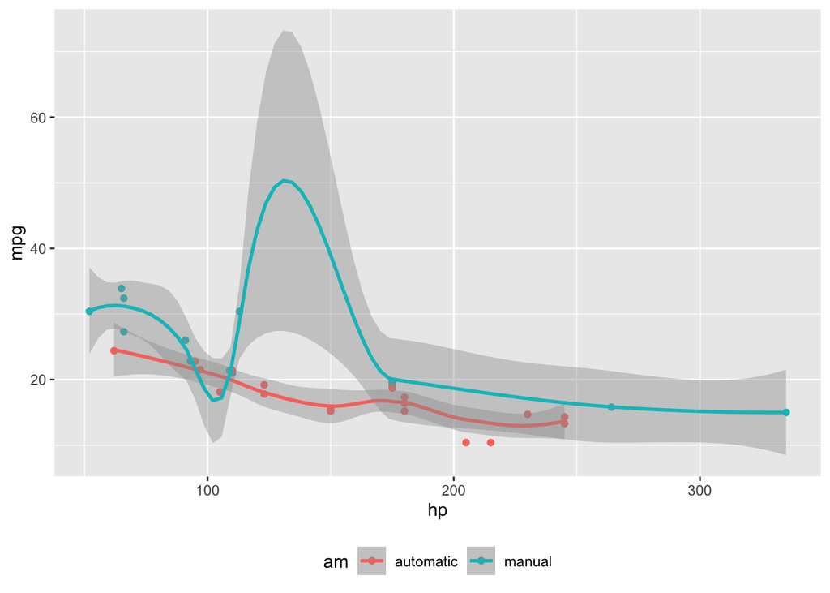

Figura 1: MPG vs HP, by transmission.

````markdown
```{r}
#| label: fig-margin
#| fig-cap: "MPG vs HP, by transmission."
#| column: margin
#| message: false
library(ggplot2)
mtcars2 <- mtcars
mtcars2$am <- factor(
  mtcars$am, labels = c('automatic', 'manual')
)
ggplot(mtcars2, aes(hp, mpg, color = am)) +
  geom_point() + geom_smooth() +
  theme(legend.position = 'bottom')
```
````

Note the use of the `fig-cap` chunk option to provide a figure caption. You can adjust the proportions of figures using the `fig-width` and `fig-height` chunk options. These are specified in inches, and will be automatically scaled down to fit within the handout margin.

## Arbitrary Margin Content

You can include anything in the margin by places the class `.column-margin` on the element. See an example on the right about the first fundamental theorem of calculus.

We know from *the first fundamental theorem of calculus* that for $x$ in $[a, b]$:

$$\frac{d}{dx}\left( \int_{a}^{x} f(u)\,du\right)=f(x).$$

## Full Width Figures

You can arrange for figures to span across the entire page by using the chunk option `fig-column: page-right`.

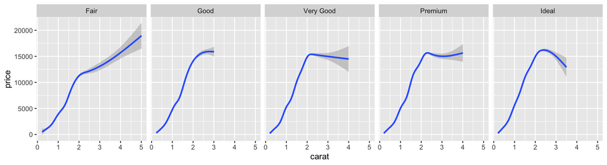

Figura 2: A full width figure.

````markdown
```{r}
#| label: fig-fullwidth
#| fig-cap: "A full width figure."
#| fig-width: 11
#| fig-height: 3
#| fig-column: page-right
#| warning: false
ggplot(diamonds, aes(carat, price)) + geom_smooth() +
  facet_grid(~ cut)
```
````

Other chunk options related to figures can still be used, such as `fig-width`, `fig-cap`, and so on. For full width figures, usually `fig-width` is large and `fig-height` is small. In the above example, the plot size is $11 \times 3$.

## Arbitrary Full Width Content

```markdown
::: {.fullwidth}
Any _full width_ content here.
:::
```

Below is an example:

*R is free software and comes with ABSOLUTELY NO WARRANTY.* You are welcome to redistribute it under the terms of the GNU General Public License versions 2 or 3. For more information about these matters see https://www.gnu.org/licenses/.

## Main Column Figures

Besides margin and full width figures, you can of course also include figures constrained to the main column. This is the default type of figures in the LaTeX/HTML output.

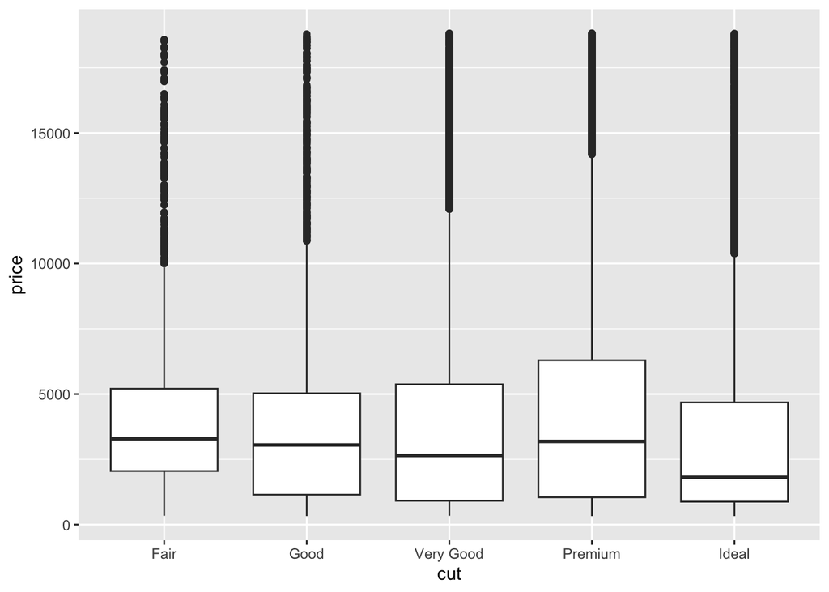

Figura 3: A figure in the main column.

````markdown
```{r}
#| label: fig-main
#| fig-cap: "A figure in the main column."
ggplot(diamonds, aes(cut, price)) + geom_boxplot()
```
````

## Margin Captions

When you include a figure constrained to the main column, you can choose to place the figure’s caption in the margin by using the `cap-location` chunk option. For example:

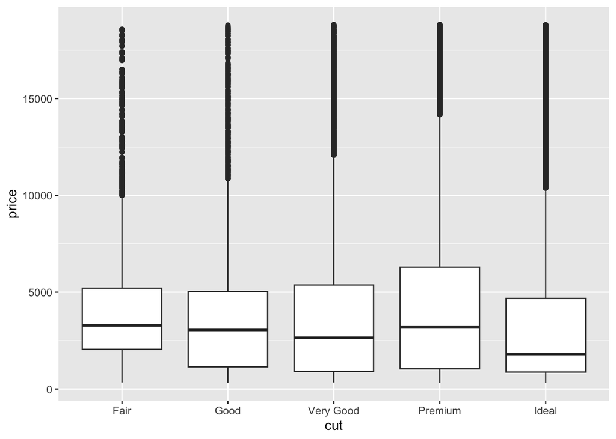

````markdown
```{r}
#| label: fig-main-margin-cap
#| fig-cap: "A figure with a longer caption. The figure appears in the main column, but the caption is placed in the margin. Captions can even contain elements like a citation such as @xie2018."
#| cap-location: margin
ggplot(diamonds, aes(cut, price)) + geom_boxplot()
```
````

# Sidenotes

One of the most prominent and distinctive features of this style is the extensive use of sidenotes. There is a wide margin to provide ample room for sidenotes and small figures. Any use of a footnote will automatically be converted to a sidenote.

If you’d like to place ancillary information in the margin without the sidenote mark (the superscript number), you can use apply the `column-margin` class to the element.

This is a span that has the class `column-margin` which places it in the margin without the sidenote mark.

# References

This feature depends upon `link-citations` to locate and place references in the margin. This is enabled by default, but if you disable `link-citations` then references in the HTML output will be placed at the end of the output document as they normally are.

# Tables

You can use the `kable()` function from the **knitr** package to format tables that integrate well with the rest of the Tufte handout style. The table captions are placed in the margin like figures in the HTML output.

````markdown
```{r}
#| tbl-cap-location: margin
knitr::kable(
  mtcars[1:6, 1:6], caption = 'A subset of mtcars.'
)
```
````

|  | mpg | cyl | disp | hp | drat | wt |
| --- | --- | --- | --- | --- | --- | --- |
| Mazda RX4 | 21.0 | 6 | 160 | 110 | 3.90 | 2.620 |
| Mazda RX4 Wag | 21.0 | 6 | 160 | 110 | 3.90 | 2.875 |
| Datsun 710 | 22.8 | 4 | 108 | 93 | 3.85 | 2.320 |
| Hornet 4 Drive | 21.4 | 6 | 258 | 110 | 3.08 | 3.215 |
| Hornet Sportabout | 18.7 | 8 | 360 | 175 | 3.15 | 3.440 |
| Valiant | 18.1 | 6 | 225 | 105 | 2.76 | 3.460 |

A subset of mtcars.

# Responsiveness

The HTML page layout is responsive- as the page width shrinks, elements will automatically adjust their position. Elements that appear in the margins will move inline with the content and elements that span the body and margin will automatically span only the body.

# More Examples

The rest of this document consists of a few test cases to make sure everything still works well in slightly more complicated scenarios. First we generate two plots in one figure environment with the chunk option `fig-show: hold`:

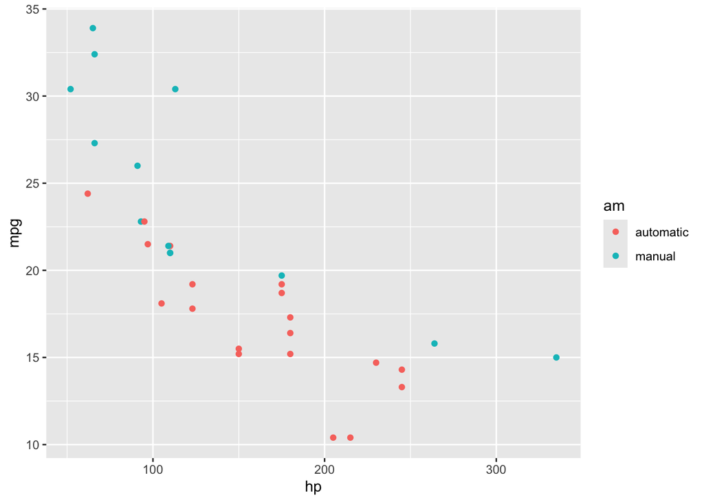

Figura 5: Two plots in one figure environment.

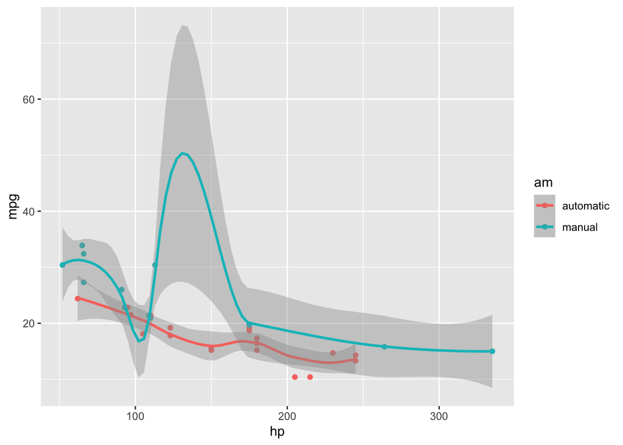

Figura 6: Two plots in one figure environment.

````markdown
```{r}
#| label: fig-two-together
#| fig-cap: "Two plots in one figure environment."
#| fig-show: hold
#| warning: false
#| cap-location: margin
p <- ggplot(mtcars2, aes(hp, mpg, color = am)) +
  geom_point()
p
p + geom_smooth()
```
````

Then two plots in separate figure environments (the code is identical to the previous code chunk, but the chunk option is the default `fig-show: asis` now):

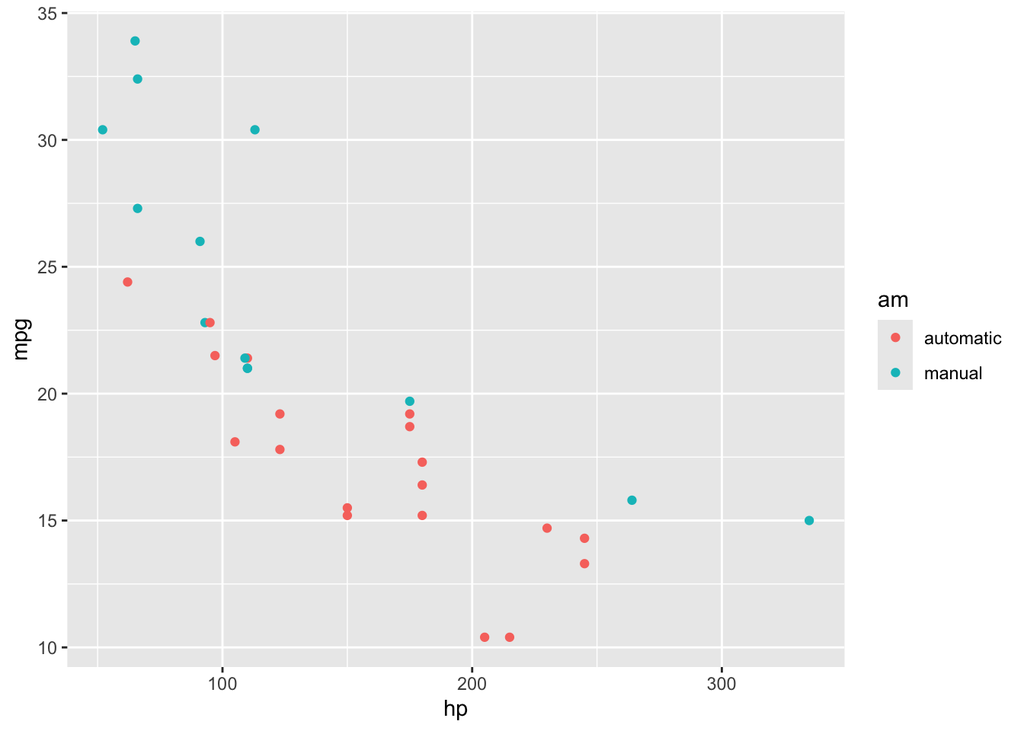

Figura 7: Two plots in separate figure environments (the first plot).

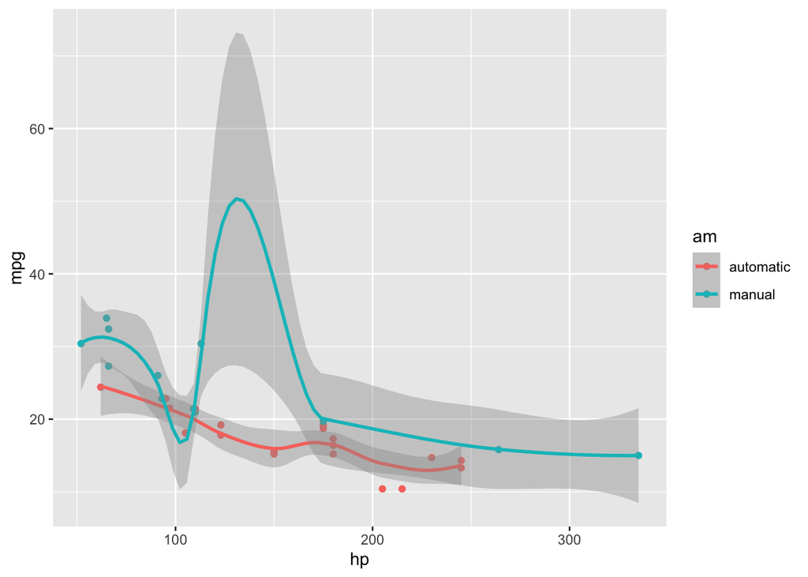

Figura 8: Two plots in separate figure environments (the second plot).

````markdown
```{r fig-two-separate, ref.label='fig-two-together', fig.cap=sprintf("Two plots in separate figure environments (the %s plot).", c("first", "second")), message=FALSE}
#| cap-location: margin
p <- ggplot(mtcars2, aes(hp, mpg, color = am)) +
  geom_point()
p
p + geom_smooth()
```
````

You may have noticed that the two figures have different captions, and that is because we used a character vector of length 2 for the chunk option `fig.cap` (something like `fig.cap = c('first plot', 'second plot')`).

**TipUsing R within Chunk Options**

If you wish to use raw R expressions as part of the chunk options (like above), then you need to define those in the `tag=value` format within the curly brackets `{r label, tag=value}` instead of the `tag: value` YAML syntax on a new line starting with the hashpipe `#|`. The former approach is documented on [knitr’s website](https://yihui.org/knitr/options/) while the latter is explained in [Quarto’s documentation](https://quarto.org/docs/reference/cells/cells-knitr.html).

Next we show multiple plots in margin figures. Similarly, two plots in the same figure environment in the margin:

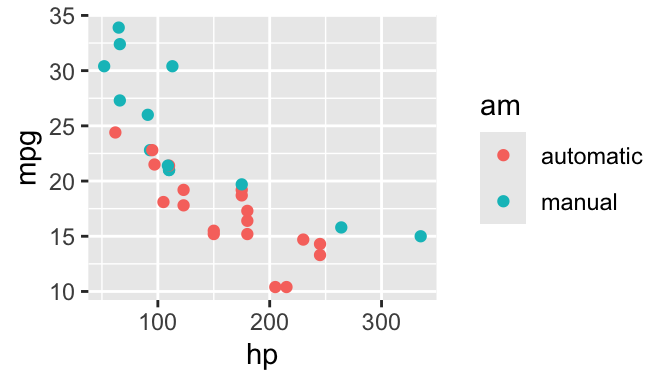

Figura 9: Two plots in one figure environment in the margin.

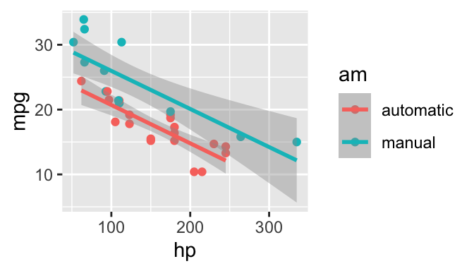

Figura 10: Two plots in one figure environment in the margin.

Then two plots from the same code chunk placed in different figure environments:

| Sepal.Length | Sepal.Width | Petal.Length | Petal.Width |
| --- | --- | --- | --- |
| 5.1 | 3.5 | 1.4 | 0.2 |
| 4.9 | 3.0 | 1.4 | 0.2 |
| 4.7 | 3.2 | 1.3 | 0.2 |
| 4.6 | 3.1 | 1.5 | 0.2 |
| 5.0 | 3.6 | 1.4 | 0.2 |
| 5.4 | 3.9 | 1.7 | 0.4 |
| 4.6 | 3.4 | 1.4 | 0.3 |
| 5.0 | 3.4 | 1.5 | 0.2 |
| 4.4 | 2.9 | 1.4 | 0.2 |
| 4.9 | 3.1 | 1.5 | 0.1 |
| 5.4 | 3.7 | 1.5 | 0.2 |
| 4.8 | 3.4 | 1.6 | 0.2 |
| 4.8 | 3.0 | 1.4 | 0.1 |

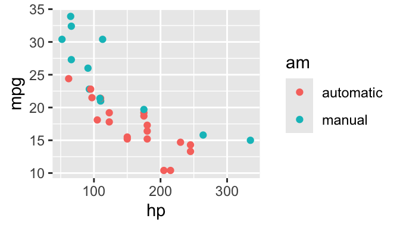

Figura 11: Two plots in separate figure environments in the margin

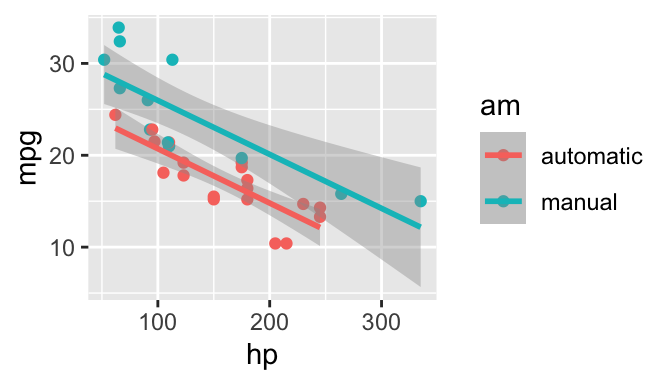

Figura 12: Two plots in separate figure environments in the margin

| Sepal.Length | Sepal.Width | Petal.Length | Petal.Width |
| --- | --- | --- | --- |
| 5.1 | 3.5 | 1.4 | 0.2 |
| 4.9 | 3.0 | 1.4 | 0.2 |
| 4.7 | 3.2 | 1.3 | 0.2 |
| 4.6 | 3.1 | 1.5 | 0.2 |
| 5.0 | 3.6 | 1.4 | 0.2 |
| 5.4 | 3.9 | 1.7 | 0.4 |
| 4.6 | 3.4 | 1.4 | 0.3 |
| 5.0 | 3.4 | 1.5 | 0.2 |
| 4.4 | 2.9 | 1.4 | 0.2 |
| 4.9 | 3.1 | 1.5 | 0.1 |
| 5.4 | 3.7 | 1.5 | 0.2 |

We blended some tables in the above code chunk only as *placeholders* to make sure there is enough vertical space among the margin figures, otherwise they will be stacked tightly together. For a practical document, you should not insert too many margin figures consecutively and make the margin crowded.

You do not have to assign captions to figures. We show three figures with no captions below in the margin, in the main column, and in full width, respectively.

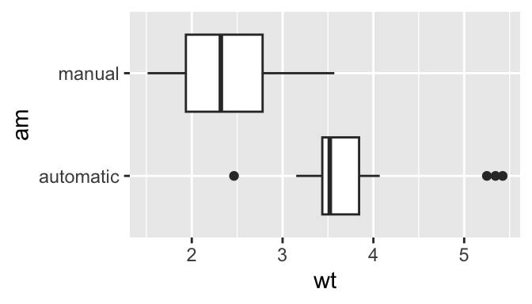

````markdown
```{r}
#| fig-width: 3.5
#| fig-height: 2
#| column: margin
# a boxplot of weight vs transmission; this figure
# will be placed in the margin
ggplot(mtcars2, aes(am, wt)) + geom_boxplot() +
  coord_flip()
```
````

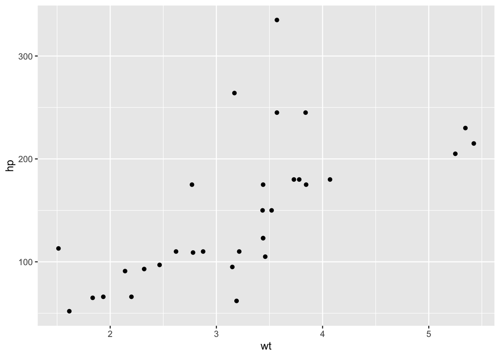

````markdown
```{r}
#| warning: false
# a figure in the main column
p <- ggplot(mtcars, aes(wt, hp)) + geom_point()
p
```
````

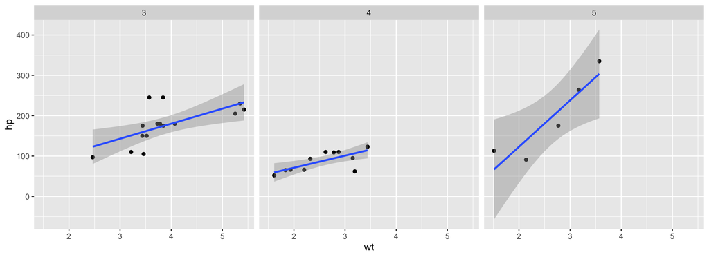

````markdown
```{r}
#| fig-width: 11
#| fig-height: 4
#| column: page-right
#| warning: false
# a fullwidth figure
p + geom_smooth(method = 'lm') + facet_grid(~ gear)
```
````